# MATH 463: Project 1

Mary Chun, James Heryanto, Yeting Li

4/27/2022

### Loading Libraries and Data

```r
library(tidyverse)
library(openintro)
library(knitr)
library(infer)

gamesales <- read_csv("GameSales.csv")
```

### Abstract

The ever-increasing technological advancements in computing and graphics power has contributed to the growth of the video game industry. Hence, we desire to step into this industry as well by opening a gaming retail store that sells and exports various types of games and gaming merchandise. In this investigation, we will determine the optimal location for the store and the most profitable video games to sell by analyzing the genre, the year of release, and the platform of the video games using the ANOVA test. Also, we will conduct a linear regression analysis of the Critic Scores and the User Scores to determine which metric is more effective in helping us to predict which games to sell in our gaming retail store based on the ratings. The ANOVA test results indicated that the types of games with high demands in the market had: 1) Genres of Platform and Shooter, 2) Release years of 1984, 1985, 1988, 1989, 1990, and 2020, and on 3) Gaming platforms of GB, 3DO, GG, NES, PCFX, SCD, TG16, and WS. The linear regression analysis results indicated that the Critic Scores is a more valid and effective rating metric to take into consideration when determining what games to sell in our gaming retail store.

### Introduction

Games are a huge part of many individuals in today’s world. In fact, many people today can finance their living by just playing games. In the early years, video games could be quite profitable with minimal development costs as the games created by a single or a small team of programmers and designers could sell hundreds of thousands of copies each. However, beginning in the 1970s, the age of video game consoles has come to its ninth generation in the 2020s, and higher definitions of graphics were allowed due to technological advancements. Hence, as computing and graphics power increased, so too did the size of development teams, as larger staffs were needed to address the ever-increasing technical and design complexities including programmers, artists, game designers, and producers.

Realizing that the video game industry is rising and will continue to rise, we want to seize this opportunity by opening a new gaming retail store that sells and exports different games and other gaming merchandise. In order to do so, we first want to explore which country has the highest demand for games, what types of games (genre) have high demand in the market, and whether the publisher of the game, the year the game was released, the platform of the game, and the game’s ratings determines its sales.

### Exploratory Data Analysis

For our research, we are focusing on the sales of video games in different regions to be our dependent variable. As for the independent variables, we have Genre, Year_of_Release, and Platform. Furthermore, we are going to separately analyze and compare the difference between the User_Score and the Critic_Score in determining the Global sales, other than the fact that User_Score is scaled out of 10 while Critic_Score is scaled out of 100 and that User_Score is a score given by Metacritic’s subscribers while Critic_Score is a score compiled by Metacritic staff.

The statistics of interest in our research is the amount of sales of video games sold in different regions of North America, European Union, Japan, and the rest of the world (in millions of units). There exists missing data in the User_Score and the Critic_Score data set. Later, we will proceed with our comparative analysis between the difference in User_Score and the Critic_Score by eliminating the missing values in these data sets.

```r
graph1 <- gamesales %>%
  summarise_at(vars(c(NA_Sales, EU_Sales, JP_Sales, Other_Sales, Global_Sales)), mean)

glimpse(graph1)
```

```
## Rows: 1
## Columns: 5
## $ NA_Sales     <dbl> 0.2633303
## $ EU_Sales     <dbl> 0.1450248
## $ JP_Sales     <dbl> 0.07760213
## $ Other_Sales  <dbl> 0.04733178
## $ Global_Sales <dbl> 0.5335427
```

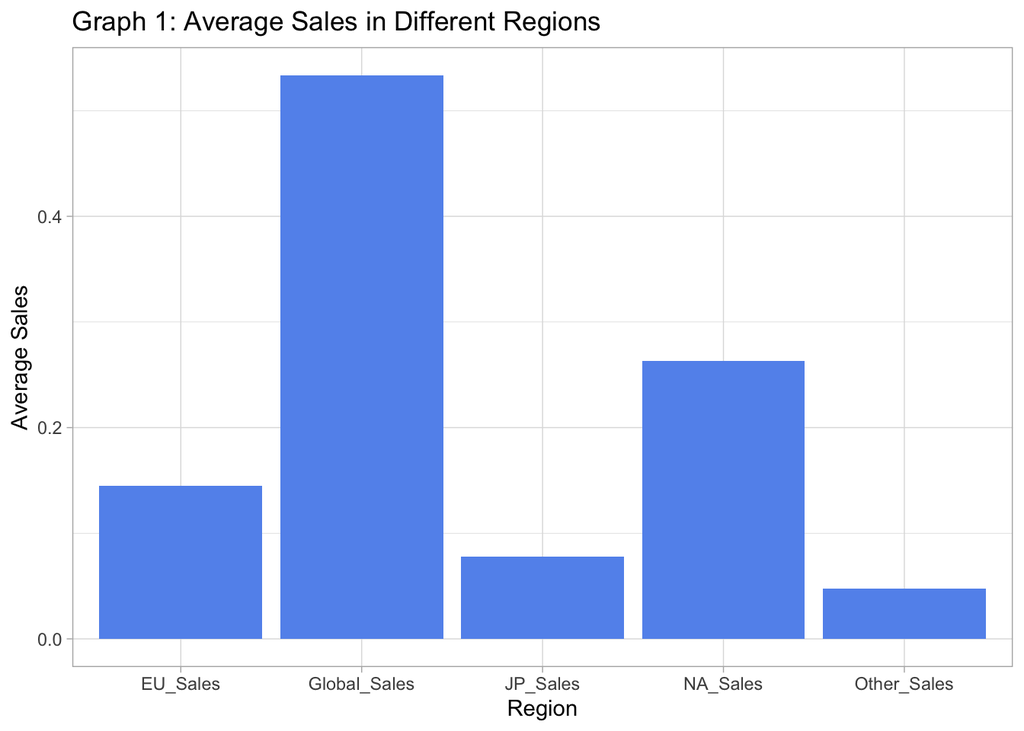

```r
df <- data.frame(Region=rep(c('NA_Sales', "EU_Sales", "JP_Sales", "Other_Sales", "Global_Sales"), each=1),
                 Sales=c(0.2633303,0.1450248, 0.07760213, 0.04733178, 0.5335427))

ggplot(data = df, aes(y = Sales, x = Region)) +
  geom_col(fill = "cornflowerblue") +
  labs(y = "Average Sales",
       title = "Graph 1: Average Sales in Different Regions") +
  theme_light()
```

Looking at the graph, the average sales in North America is the highest, followed by Europe, then Japan, and finally other countries.

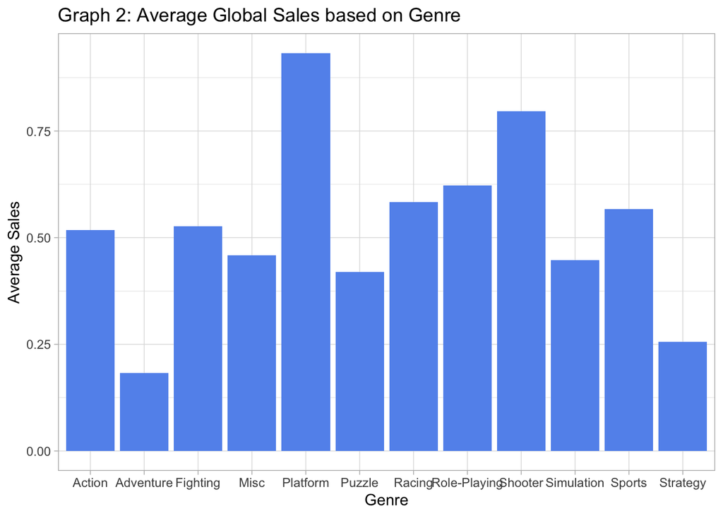

```r
graph2 <- gamesales %>%
  filter(!is.na(Genre)) %>%
  group_by(Genre) %>%
  summarise_at(vars(c(Global_Sales)), mean) %>%
  pivot_longer(!Genre, names_to = "stat", values_to = "count")

ggplot(data = graph2, aes(y = count, x = Genre)) +
  geom_bar(stat = "identity",
           position = position_dodge(),
           fill = "cornflowerblue") +
  labs(x = "Genre",
       y = "Average Sales",
       title = "Graph 2: Average Global Sales based on Genre") +
  theme_light()
```

Looking at the graph, the global average sales is the highest for the genre of “Platform.” This genre usually features two-dimensional graphics in which players control characters who jump or climb between different platforms on the screen.

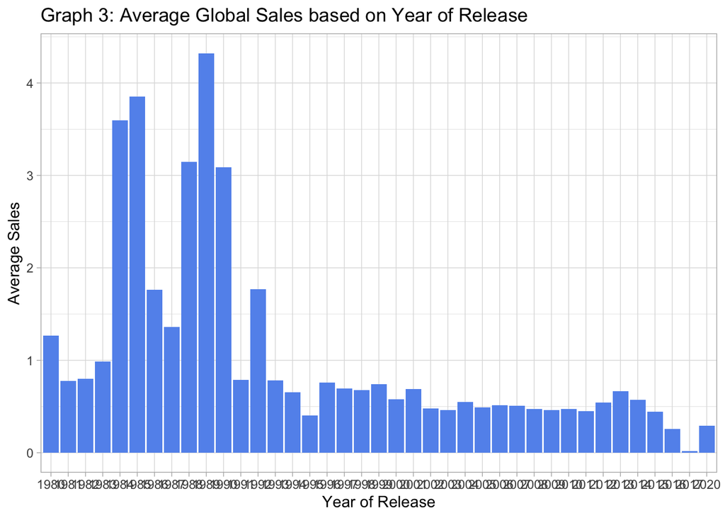

```r
graph3 <- gamesales %>%
  filter(Year_of_Release != "N/A") %>%
  group_by(Year_of_Release) %>%
  summarise_at(vars(c(Global_Sales)), mean) %>%
  pivot_longer(!Year_of_Release, names_to = "stat", values_to = "count")

ggplot(data = graph3, aes(y = count, x = Year_of_Release)) +
  geom_bar(stat = "identity",
           position = position_dodge(),
           fill = "cornflowerblue") +
  labs(x = "Year of Release",
       y = "Average Sales",
       title = "Graph 3: Average Global Sales based on Year of Release") +
  theme_light()
```

Looking at the graph, the global average sales is the highest in the year 1989 out of all other years of release.

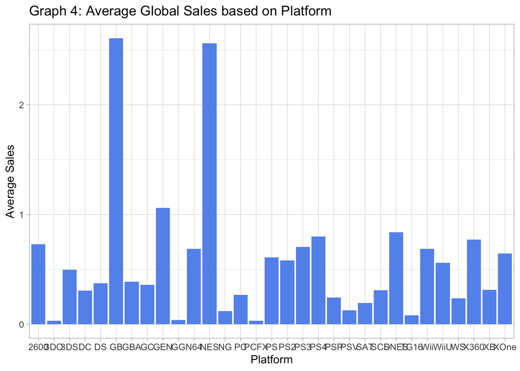

```r
graph4 <- gamesales %>%
  group_by(Platform) %>%
  summarise_at(vars(c(Global_Sales)), mean) %>%
  pivot_longer(!Platform, names_to = "stat", values_to = "count")

ggplot(data = graph4, aes(y = count, x = Platform)) +
  geom_bar(stat = "identity",
           position = position_dodge(),
           fill = "cornflowerblue") +
  labs(x = "Platform",
       y = "Average Sales",
       fill = "Regions",
       title = "Graph 4: Average Global Sales based on Platform") +
  theme_light()
```

Looking at the graph, the global average sales is the highest for the GB (Game Boy) platform among other consoles on which the game is running.

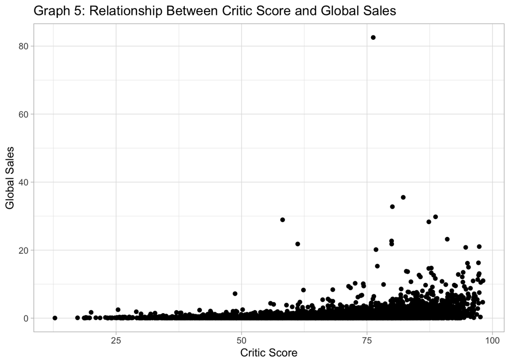

```r
ggplot(data = gamesales, aes(x = Critic_Score, y = Global_Sales)) +
  geom_jitter() +
  labs(x = "Critic Score",
       y = "Global Sales",
       title = "Graph 5: Relationship Between Critic Score and Global Sales") +
  theme_light()
```

Looking at the graph, we observe a linear relationship between the critic score and the global sales.

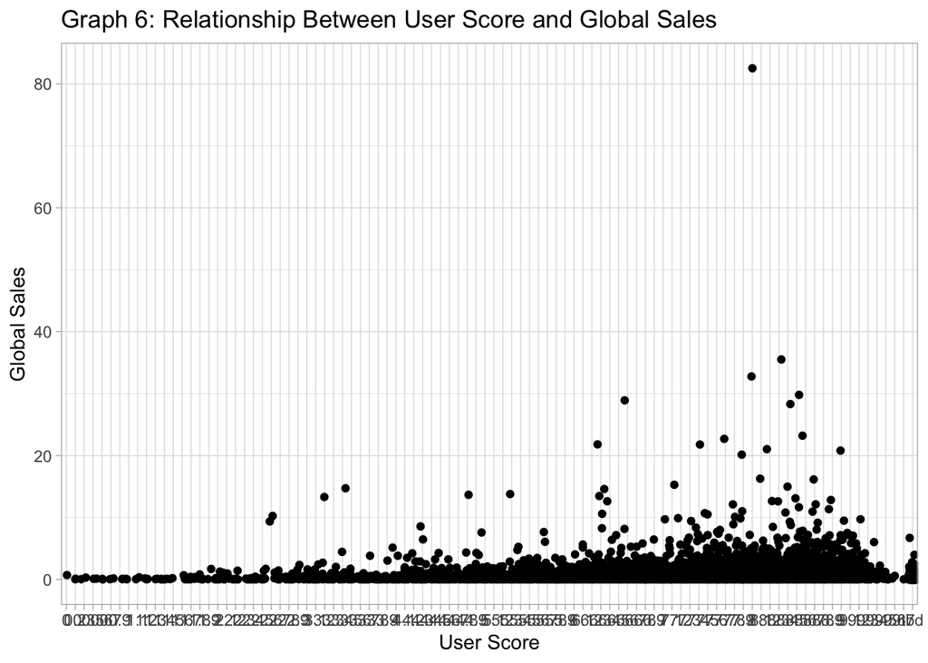

```r
ggplot(data = gamesales %>% filter(!is.na(User_Score)), aes(x = User_Score, y = Global_Sales)) +
  geom_jitter() +
  labs(x = "User Score",
       y = "Global Sales",
       title = "Graph 6: Relationship Between User Score and Global Sales") +
  theme_light()
```

Looking at the graph, we observe a linear relationship between the user score and the global sales.

### Statistical Analysis

Based on the previous section, we see that the genre of Platform has the highest global sales average. In order to make sure that is the case, we are conducting the ANOVA test. With ANOVA, we have evidence that Platform has different global sales compared to Puzzle (p-value = 0.0000001), Racing (p-value = 0.0000157), Role-Playing (p-value = 0.0001293), Simulation (p-value = 0.0000000), Sports (p-value = 0.0000001), Strategy (p-value = 0.0000000), Adventure (p-value = 0.0000000), Action (p-value = 0.0000000), Fighting (p-value = 0.0000027), and Misc (p-value = 0.0000000). However, there does not seem to be a significant difference with Shooter as the p-value is pretty high (p-value = 0.6610054).

```r
#TukeyHSD(aov(Global_Sales~Genre, data=gamesales))

table1 <- data.frame(Genre=c('Puzzle-Platform', 'Racing-Platform', 'Role-Playing-Platform', 'Simulation-Platform', 'Sports-Platform', 'Strategy-Platform', 'Platform-Adventure', 'Platform-Action', 'Platform-Fighting', 'Platform-Mise', 'Platform-Shooter'),
                 Pvalue=c(0.0000001, 0.0000157, 0.0001293, 0.0000000, 0.0000001, 0.0000000, 0.0000000, 0.0000000, 0.0000027, 0.0000000,0.6610054))

kable(table1)
```

| Genre | Pvalue |
| --- | --- |
| Puzzle-Platform | 0.0000001 |
| Racing-Platform | 0.0000157 |
| Role-Playing-Platform | 0.0001293 |
| Simulation-Platform | 0.0000000 |
| Sports-Platform | 0.0000001 |
| Strategy-Platform | 0.0000000 |
| Platform-Adventure | 0.0000000 |
| Platform-Action | 0.0000000 |
| Platform-Fighting | 0.0000027 |
| Platform-Mise | 0.0000000 |
| Platform-Shooter | 0.6610054 |

Furthermore, as for the year of release, based on the previous section, we see that 1989 has the highest global sales average. Same as for genre, in order to make sure that is the case, we are conducting the ANOVA test. With ANOVA, we have evidence that games released in 1989 have higher global sales compared to other years as the p-values for comparing the year 1989 and other years are relatively low. However, for the years 1984, 1985, 1988, 1990, and 2020 we fail to reject the null hypothesis, indicating that their global sales are pretty much similar to the global sales of games released in 1989 as their p-values are relatively high (0.9999998, 1.0000000, 0.9836611, 0.9563883, 0.8574997, respectively).

```r
#TukeyHSD(aov(Global_Sales~Year_of_Release, data=gamesales))

table2 <- data.frame(YearOfRelease=c('1989-1984', '1989-1985', '1989-1988', '1989-1990', '1989-2020'),
                 Pvalue=c(0.9999998, 1.0000000, 0.9836611, 0.9563883, 0.8574997))

kable(table2)
```

| YearOfRelease | Pvalue |
| --- | --- |
| 1989-1984 | 0.9999998 |
| 1989-1985 | 1.0000000 |
| 1989-1988 | 0.9836611 |
| 1989-1990 | 0.9563883 |
| 1989-2020 | 0.8574997 |

```r
#TukeyHSD(aov(Global_Sales~Platform, data=gamesales))

table3 <- data.frame(Platform=c('GB-3DO','GG-GB','NES-GB','PCFX-GB', 'SCD-GB', 'TG16-GB', 'WS-GB'),
                 Pvalue=c(0.4899338, 0.9988369, 1.0000000, 0.9987551, 0.8932125, 0.0892733, 0.0612600))

kable(table3)
```

| Platform | Pvalue |
| --- | --- |
| GB-3DO | 0.4899338 |
| GG-GB | 0.9988369 |
| NES-GB | 1.0000000 |
| PCFX-GB | 0.9987551 |
| SCD-GB | 0.8932125 |
| TG16-GB | 0.0892733 |
| WS-GB | 0.0612600 |

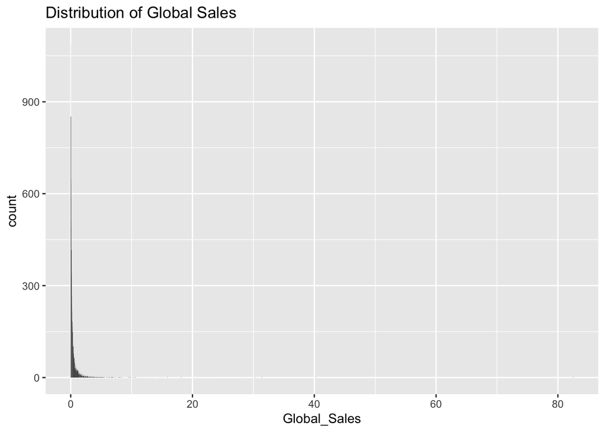

```r
ggplot(data = gamesales, aes(x = Global_Sales)) +
  geom_bar(bins = 30) +
  labs(title = "Distribution of Global Sales")
```

Next, we also want to analyze if we there is any connection between critic scores and global sales. In order to do so, we create a linear model. The equation of the linear model that we obtain is y = -1.517566 + 0.031995x, which means that for an increase in critic score, the global sales increases by 0.031995. Furthermore, the p-value for the slope is relatively small where it is less than 2e-16. Therefore, we have evidence that the slope is significantly different from 0.

```r
mCritic <- lm(Global_Sales ~ Critic_Score, data = gamesales)
#summary(mCritic)

table4 <- data.frame(Coefficients=c('Intercept', 'Critic Score'),
                 Estimate=c(-1.517566, 0.031995),
                 Pvalue=c('<2e-16', '<2e-16'))

kable(table4)
```

| Coefficients | Estimate | Pvalue |
| --- | --- | --- |
| Intercept | -1.517566 | <2e-16 |
| Critic Score | 0.031995 | <2e-16 |

Similarly, we want to see if there is any relationship between user scores and global sales. The equation of the linear model that we obtain in this case is y = -0.0459 + 0.1102x, which means that for an increase in user score, the global sales increases by 0.1102. Furthermore, the p-value for the slope is relatively small where it is approximately 1.44e-14. Therefore, we have evidence that the slope is significantly different from 0.

```r
gamesales <- gamesales %>% mutate(User_Scorenew = as.numeric(User_Score))
mUser <- lm(Global_Sales ~ User_Scorenew, data = gamesales)
#summary(mUser)

table5 <- data.frame(Coefficients=c('Intercept', 'Use Score'),
                 Estimate=c(-0.0459, 0.1102),
                 Pvalue=c('0.659', '1.44e-14'))

kable(table5)
```

| Coefficients | Estimate | Pvalue |
| --- | --- | --- |
| Intercept | -0.0459 | 0.659 |
| Use Score | 0.1102 | 1.44e-14 |

### Conclusion

In this research, we desired to determine what type of video games, which video game platforms to sell, and what locations to sell these games to in order to operate our gaming retail store most effectively. After completing the exploratory data analysis, we observed that almost half of the global sales constituted the sales from North America. Hence, we conclude that our gaming retail store will be located in North America.

Then, we investigated the global sales of video games by assessing the variables of genre, years of release, and platform using the ANOVA test.

For the variable of Genre, the ANOVA test supported our previous observation that the Platform genre has the highest global sales average in our exploratory data analysis. We have evidence that Platform has higher global sales average compared to Puzzle, Racing, Role-Playing, Simulation, Sports, Strategy, Adventure, Action, Fighting, and Misc. Yet, there does not seem to be a significant difference with the genre of Shooter. Hence, we conclude that the Platform and the Shooter genre have high demands in the market and thus the two profitable video games to sell in our gaming retail store.

For the variable of Year_of_Release, the ANOVA test supported our previous observation that the games released in the year 1989 had the highest global sales average in our exploratory data analysis. We have evidence that in the time period of 1980 to 2020, the games released in 1989 had higher global sales average compared to the other years, except in the years of 1984, 1985, 1988, 1990, and 2020. In other words, we found that the global sales average of games released in these five years were indifferent compared to the global sales average of the games released in the year 1989. Therefore, we conclude that video games released in 1984, 1985, 1988, 1989, 1990, and 2020 have high demands in the market and thus the profitable video games to sell in our gaming retail store.

For the variable of Platform, the ANOVA test indicated that there is no significant difference in global sales average between GB (Game Boy) and the gaming platforms of 3DO, GG, NES, PCFX, SCD, TG16, and WS. However, the global sales average of GB was significantly different to the rest of the other gaming platforms. From our previous exploratory data analysis, we observed that the platforms of GB and NES have significantly higher global sales averages compared to the other platforms. Hence, we conclude that gaming platforms of GB, 3DO, GG, NES, PCFX, SCD, TG16, and WS and the video games performed in these platforms have high demands in the market and thus the profitable games and merchandise to sell in our gaming retail store.

Afterward, we conducted a linear regression analysis of the Critic Scores and the User Scores to determine which metric is more effective in helping us to predict which games to sell in our gaming retail store based on the ratings.

The first step was to examine the relationship between Critic Scores and global sales. We observed that the slope of 0.031995 in our linear model equation is significantly different from 0. Hence, we conclude that the Critic Scores is a valid predictor of the global sales of video games and thus a valid source of rating video games as well.

The second step was to examine the relationship between User Scores and global sales. We observed that the slope of 0.1102 in our linear model equation is significantly different from 0. Hence, we conclude that the User Scores is a valid predictor of the global sales of video games and thus a valid source of rating video games as well.

By comparing the p-values of these two linear regression models, we observed that the p-value of the Critic Scores vs. global sales model is significantly lower. Therefore, we conclude that the Critic Scores is a more valid and effective rating metric to take into consideration when determining what games to sell in our gaming retail store.